# Assess cancer predisposition gene expression in PBTA germline cohort

Ryan Corbett

This script compares genes expression z-scores in patients with vs. without germline pathogenic/likely pathogenic (P/LP) variants in PBTA germline cohort.

# Load libraries

```r
suppressPackageStartupMessages({
  library(ggplot2)
  library(tidyverse)
  library(ggpubr)
  library(ggrepel)
})

# Set up directories
root_dir <- rprojroot::find_root(rprojroot::has_dir(".git"))

data_dir <- file.path(root_dir, "data")
analysis_dir <- file.path(root_dir, "analyses", "two-hits")
input_dir <- file.path(analysis_dir, "input")
results_dir <- file.path(analysis_dir, "results")
plot_dir <- file.path(analysis_dir, "plots")

# If the directory does not exist, create it
if (!dir.exists(results_dir)) {
  dir.create(results_dir, recursive = TRUE)
}

# source publication theme
source(file.path(root_dir, "figures", "theme.R"))

# set seed to reproduce plots
set.seed(2023)
```

Set input file paths

```r
# plp_file <- file.path(data_dir,
#                       "pbta-merged-plp-variants-autogvp-abridged.tsv")
plp_file <- file.path(results_dir,
                      "germline-plp-variants-cpg-somatic-driver-in-tumor.tsv")

plp_sv_file <- file.path(data_dir,
                         "pbta_germline_svs.tsv")

histologies_file <- file.path(data_dir,
                              "histologies.tsv")

hist_cohort_file <- file.path(root_dir, "analyses",
                              "collapse-tumor-histologies", "results",
                              "germline-primary-plus-tumor-histologies-plot-groups-clin-meta.tsv")

expr_file <- file.path(data_dir, "gene-expression-rsem-tpm-collapsed.rds")

# cpg file
cpg_file <- file.path(root_dir, "analyses", "oncokb-annotation", "input", "cpg.txt")
hgat_file <- file.path(root_dir, "analyses", "variant-distribution", "input", "hgat_goi_list.tsv")
lgat_file <- file.path(root_dir, "analyses", "variant-distribution", "input", "lgat_goi_list.tsv")
embryonal_file <- file.path(root_dir, "analyses", "variant-distribution", "input", "embryonal-tumor_goi_list.tsv")
other_file <- file.path(root_dir, "analyses", "variant-distribution", "input", "other_goi_list.tsv")
```

# Load files

```r
hist <- read_tsv(histologies_file)
hist_cohort <- read_tsv(hist_cohort_file)
# CPGs
cpgs <- read_lines(cpg_file)
hgat_drivers <- read_lines(hgat_file)
lgat_drivers <- read_lines(lgat_file)
embryonal_drivers <- read_lines(embryonal_file)
other_drivers <- read_lines(other_file)
somatic_drivers <- c(hgat_drivers, lgat_drivers, embryonal_drivers, other_drivers)
```

Read in germline plp file, and append coordinate and ref/alt allele info

```r
# Load abridged P/LP file and append variant coordinates
germline <- read_tsv(plp_file)
germline_sv <- read_tsv(plp_sv_file) %>%
  dplyr::rename(Hugo_Symbol = Hugo_Symbol_cpg) %>%
  dplyr::filter(Kids_First_Biospecimen_ID_normal %in% hist_cohort$Kids_First_Biospecimen_ID_normal)
```

Extract tumor RNA IDs from hist file, and append to `germline` NOTE: we will define SHH-MB and SEGA tumors separately from MB and LGG, respectively, in this analysis, given that specific CPGs are P-LP only in these tumor types (i.e., PTCH1 and SUFU in SHH-MB and TSC1/2 in SEGA).

```r
rna_specimens <- read_tsv(file.path(data_dir, "independent-specimens.rnaseqpanel.primary-plus.tsv")) %>%
  dplyr::rename(Kids_First_Biospecimen_ID_rna = Kids_First_Biospecimen_ID)
hist_cohort <- read_tsv(hist_cohort_file) %>%
  dplyr::rename(Kids_First_Biospecimen_ID = Kids_First_Biospecimen_ID_tumor) %>%
  left_join(hist %>% dplyr::select(Kids_First_Biospecimen_ID,
                                   match_id)) %>%
  left_join(hist %>% dplyr::filter(experimental_strategy == "RNA-Seq") %>%
              dplyr::rename(Kids_First_Biospecimen_ID_rna = Kids_First_Biospecimen_ID) %>%
              dplyr::select(match_id, Kids_First_Biospecimen_ID_rna)) %>%
  distinct(match_id, .keep_all = TRUE) %>%
  # define a "subgroup" column to distinguish SHH-MB and SEGA from MB and LGG plot groups, respectively.
  dplyr::mutate(subgroup = case_when(
    molecular_subtype == "MB, SHH" ~ "MB, SHH",
    grepl("SEGA", molecular_subtype) ~ "SEGA",
    TRUE ~ plot_group
  ))
write_tsv(hist_cohort,
          file.path(results_dir,
                    "germline-primary-plus-tumor-histologies-rna.tsv"))

# filter PLP calls for cpgs, and add plot_group and molecular_subtype
germline <- germline %>%
  left_join(hist_cohort[,c("Kids_First_Biospecimen_ID_normal",
                    "Kids_First_Biospecimen_ID_rna", "plot_group", "molecular_subtype")]) %>%
  dplyr::select(Kids_First_Biospecimen_ID_normal,
                Kids_First_Biospecimen_ID_rna,
                plot_group, molecular_subtype,
                Hugo_Symbol, autogvp_call, autogvp_call_reason,
                chr, start, ref, alt,
                HGVSc, HGVSp) %>%
  distinct(Kids_First_Biospecimen_ID_normal, Kids_First_Biospecimen_ID_rna, Hugo_Symbol, start, .keep_all = T)
germline_sv <- germline_sv %>%
  left_join(hist_cohort[,c("Kids_First_Biospecimen_ID_normal", "Kids_First_Participant_ID",
                    "Kids_First_Biospecimen_ID_rna", "plot_group", "molecular_subtype")]) %>%
  dplyr::select(Kids_First_Biospecimen_ID_normal, Kids_First_Participant_ID,
                Kids_First_Biospecimen_ID_rna,
                plot_group, molecular_subtype,
                Hugo_Symbol,
                Chromosome, Start, End, Length,
                Type, Classification) %>%
  distinct(Kids_First_Biospecimen_ID_normal, Kids_First_Biospecimen_ID_rna, Hugo_Symbol, .keep_all = T)
```

Read in gene expression RDS file, and calculate z-scores

```r
expr <- readRDS(expr_file)
# subset `expr` to only include BS IDs in hist
subset_expr <- expr[,intersect(hist_cohort$Kids_First_Biospecimen_ID_rna, colnames(expr))]

# log2(x + 1) transform the expression matrix
log_expression <- log2(subset_expr + 1)

z_scored_expression <- log_expression %>%
#  t() %>%
  as.data.frame() %>%
  rownames_to_column("Hugo_Symbol") %>%
  gather(key = "Kids_First_Biospecimen_ID_rna", value = "expr", -Hugo_Symbol) %>%
  left_join(hist_cohort %>% dplyr::select(Kids_First_Biospecimen_ID_rna, Kids_First_Biospecimen_ID_normal,
                                   plot_group, plot_group_hex, subgroup, molecular_subtype)) %>%
  group_by(Hugo_Symbol, subgroup) %>%
  dplyr::filter(Hugo_Symbol %in% c(germline$Hugo_Symbol, germline_sv$Hugo_Symbol)) %>%
  dplyr::mutate(expr_zscore = scale(expr)) %>%
  dplyr::mutate(expr_zscore = round(as.numeric(expr_zscore), 2))
write_tsv(z_scored_expression,
          file.path(results_dir, "pbta-germline-gene-expr-zscores.tsv"))
```

Append expression z-scores to genes with P/LP variants across cohort, and write to output

```r
germline_somatic_expr <- germline %>%
  left_join(z_scored_expression)
germline_somatic_expr %>%
  dplyr::filter(Hugo_Symbol %in% cpgs) %>%
  write_tsv(file.path(results_dir, "germline-somatic-expr-cpgs.tsv"))

germline_somatic_expr %>%
  dplyr::filter(!Hugo_Symbol %in% cpgs) %>%
  write_tsv(file.path(results_dir, "germline-somatic-expr-somatic-non-cpgs.tsv"))

germline_sv_somatic_expr <- germline_sv %>%
  left_join(z_scored_expression) %>%
  write_tsv(file.path(results_dir, "germline-sv-somatic-expr-cpgs.tsv"))
```

Plot gene expression z-scores in P/LP carriers

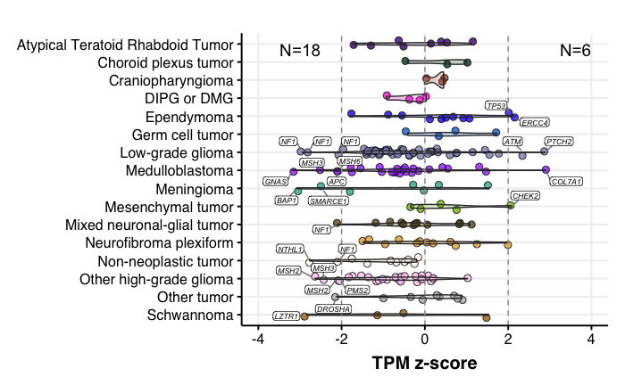

```r
expr_plot_df <- germline_somatic_expr %>%
  dplyr::filter(Hugo_Symbol %in% cpgs) %>%
  dplyr::select(Kids_First_Biospecimen_ID_normal,
                Kids_First_Biospecimen_ID_rna, plot_group,
                Hugo_Symbol, expr_zscore, molecular_subtype) %>%
  bind_rows(germline_sv_somatic_expr %>%
              dplyr::select(Kids_First_Biospecimen_ID_normal,
                            Kids_First_Biospecimen_ID_rna, plot_group,
                            Hugo_Symbol, expr_zscore)) %>%
  left_join(hist_cohort %>% dplyr::select(plot_group, plot_group_hex)) %>%
  distinct() %>%
  dplyr::mutate(gene_text = case_when(
    expr_zscore > 2 | expr_zscore < -2 ~ Hugo_Symbol,
    TRUE ~ ""
  ))
plot_group_palette <- expr_plot_df$plot_group_hex
names(plot_group_palette) <- expr_plot_df$plot_group

expr_plot_df %>%
  dplyr::mutate(plot_group = fct_relevel(plot_group,
                                         rev(sort(unique(plot_group))))) %>%

  ggplot(aes(x = expr_zscore, y = plot_group, label = gene_text)) +
  geom_jitter(aes(fill = plot_group),
              shape = 21, width = 0.05,
              height = 0.2,
              size = 2.5, alpha = 0.8,
              show.legend = FALSE) +
  geom_violin(aes(fill = plot_group),
              alpha = 0.2,
               show.legend = FALSE) +
  geom_vline(xintercept = c(-2, 0, 2), linetype = "dashed", color = "gray60") +
  geom_label_repel(aes(label = gene_text),
                  fontface = "italic",
                  size = 2.25,
                  box.padding   = 0.3,
                  label.padding = 0.1,
                  point.padding = 0.25,
                  segment.color = 'grey50',
                  min.segment.length = 0.1,
                  max.overlaps = 14) +
  annotate("text", x = 4,
           y = min(expr_plot_df$plot_group),
           label = glue::glue("N={sum(expr_plot_df$expr_zscore >= 2 & !is.na(expr_plot_df$expr_zscore))}"),
           color = "black", size = 5, hjust = 1, vjust = 1) +
    annotate("text", x = -2.5,
           y = min(expr_plot_df$plot_group),
           label = glue::glue("N={sum(expr_plot_df$expr_zscore <= -2 & !is.na(expr_plot_df$expr_zscore))}"),
           color = "black", size = 5, hjust = 1, vjust = 1) +
  scale_fill_manual(values = plot_group_palette,
                     breaks = sort(names(plot_group_palette))) +
  labs(y = NULL, x = "TPM z-score") +
  xlim(c(-4,4)) +
  theme_Publication()

ggsave(file.path(plot_dir, "germline_plp_expr_zscores.pdf"),
       width = 6, height = 6.5)
```

For assessing differences in gene expression between patients with vs. without P/LP variants, we will take a single matched tumor RNA-seq sample for each patient from independent specimens file

```r
germline_all <- germline %>%
  dplyr::select(Kids_First_Biospecimen_ID_normal, Hugo_Symbol, plot_group) %>%
  bind_rows(germline_sv %>% dplyr::select(Kids_First_Biospecimen_ID_normal, Hugo_Symbol, plot_group)) %>%
  dplyr::filter(Hugo_Symbol %in% cpgs)

z_scored_expression <- z_scored_expression %>%
  dplyr::mutate(sample_gene = glue::glue("{Kids_First_Biospecimen_ID_normal}:{Hugo_Symbol}")) %>%
  # add column indicating if patient has P/LP variant in gene
  dplyr::mutate(is_plp = case_when(
    sample_gene %in% glue::glue("{germline_all$Kids_First_Biospecimen_ID_normal}:{germline_all$Hugo_Symbol}") ~ "Yes",
    TRUE ~ "No"
  )) %>%
  distinct(Kids_First_Biospecimen_ID_normal, Kids_First_Biospecimen_ID_rna, Hugo_Symbol,
           .keep_all = TRUE)
```

Add P/LP status to `z_scored_expression` for plotting

```r
z_scored_expression <- z_scored_expression %>%
  # Only samples with P/LP variants in genes will be colored by plot group
  dplyr::mutate(plp_group = case_when(
    is_plp == "No" ~ NA_character_,
    is_plp == "Yes" ~ subgroup
  )) %>%
  distinct(Kids_First_Biospecimen_ID_rna, Hugo_Symbol, .keep_all = TRUE)

# define color palette
plot_group_palette <- z_scored_expression$plot_group_hex
names(plot_group_palette) <- z_scored_expression$plot_group
```

Plot normalized expression within histologies, for genes that have P/LP variants in >= 2 patients within histology group

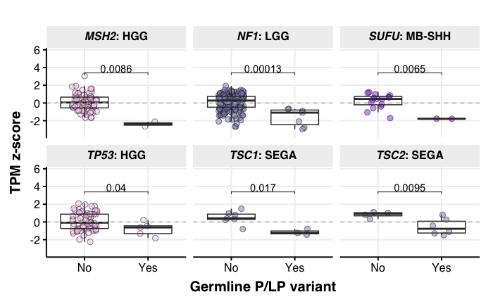

```r
# define group_gene column
z_scored_expression <- z_scored_expression %>%
  dplyr::mutate(
    subgroup_clean = subgroup %>%
      gsub("Other high-grade glioma", "HGG", .) %>%
      gsub("Low-grade glioma", "LGG", .) %>%
      gsub("MB, SHH", "MB-SHH", .) %>%
      gsub(",", "", .) %>%
      gsub(" ", "~", .),
      group_gene = glue::glue('**<i>{Hugo_Symbol}</i>: {subgroup_clean}**')
    )

# Identify histology-gene pairs for which there are at least 3 patients with P/LP variants in group
plot_group_gene <- z_scored_expression %>%
  distinct(Kids_First_Biospecimen_ID_normal, Hugo_Symbol, .keep_all = TRUE) %>%
  filter(is_plp == "Yes") %>%
  count(group_gene) %>%
  dplyr::filter(n >= 2) %>%
  pull(group_gene)

compare_means_result <- z_scored_expression %>%
  dplyr::filter(group_gene %in% plot_group_gene) %>%
  group_by(group_gene) %>%
  summarize(p_value = wilcox.test(expr_zscore ~ is_plp, alternative = "greater")$p.value)
to_plot <- compare_means_result %>%
  dplyr::filter(p_value < 0.05) %>%
  pull(group_gene)

z_scored_expression %>%
  dplyr::filter(group_gene %in% to_plot) %>%

  ggplot(aes(x = is_plp, y = expr_zscore)) +
    geom_jitter(aes(fill = plot_group), shape = 21,
                width = 0.2, size = 2.5, alpha = 0.5,
                show.legend = FALSE) +
    geom_boxplot(alpha = 0.05, outlier.shape = NA,
                   show.legend = FALSE) +
    stat_compare_means(method = "wilcox",
                       comparisons = list(c("Yes", "No")),
                       method.args = list(alternative = "less")) +
    labs(x = "Germline P/LP variant", y = "TPM z-score", fill = "Histology") +
    ylim(c(-3.5,5.75)) +
    geom_hline(yintercept = 0, linetype = "dashed", color = "gray") +
    scale_fill_manual(values = plot_group_palette,
                      breaks = sort(names(plot_group_palette))) +
    facet_wrap(~group_gene) +
    theme_Publication() +
    theme(strip.text = ggtext::element_markdown())

  ggsave(file.path(plot_dir, "hist-gene-expr-plp-vs-noplp.pdf"),
                   width = 7, height = 5)
```

```r
NA
```

We can further separate samples based on whether matched tumors have detected oncogenic/likely oncogenic SNV, which may influence gene expression

```r
# read in MAF file with oncokb annotation
maf <- read_tsv(file.path(root_dir, "analyses", "oncokb-annotation", "results", "snv-consensus-plus-hotspots-goi-oncokb.maf.tsv")) %>%
    filter(ONCOGENIC %in% c("Likely Oncogenic", "Oncogenic", "Resistance") |
           Variant_Classification %in% c("Frame_Shift_Del", "Frame_Shift_Ins",
                                         "Missense_Mutation", "Nonsense_Mutation",
                                         "Splice_Site", "Translation_Start_Site"))
loh <- read_tsv(file.path(results_dir, "germline-somatic-cnv-loh-cpgs.tsv")) %>%
  dplyr::filter(loh_status != "No LOH" & proband_tumor_vaf > 0.25)
loh_sv <- read_tsv(file.path(results_dir, "germline-sv-somatic-cnv-loh-somatic-cpgs.tsv")) %>%
  dplyr::filter(Kids_First_Biospecimen_ID_tumor %in% hist_cohort$Kids_First_Biospecimen_ID,
                loh_status == "LOH")
# append matched tumor genomic ID to z_scored_expression
z_scored_expression <- z_scored_expression %>%
  left_join(hist_cohort[,c("Kids_First_Biospecimen_ID_normal", "Kids_First_Biospecimen_ID")])
z_scored_expression <- z_scored_expression %>%
  dplyr::mutate(second_hit = case_when(
    glue::glue("{Kids_First_Biospecimen_ID}:{Hugo_Symbol}") %in% c(glue::glue("{maf$Tumor_Sample_Barcode}:{maf$Hugo_Symbol}"),
                                                                         glue::glue("{loh$Kids_First_Biospecimen_ID_tumor}:{loh$Hugo_Symbol}"),
                                                                   glue::glue("{loh_sv$Kids_First_Biospecimen_ID_tumor}:{loh_sv$Hugo_Symbol}")) ~ "Yes",
    TRUE ~ "No"
  ))
```

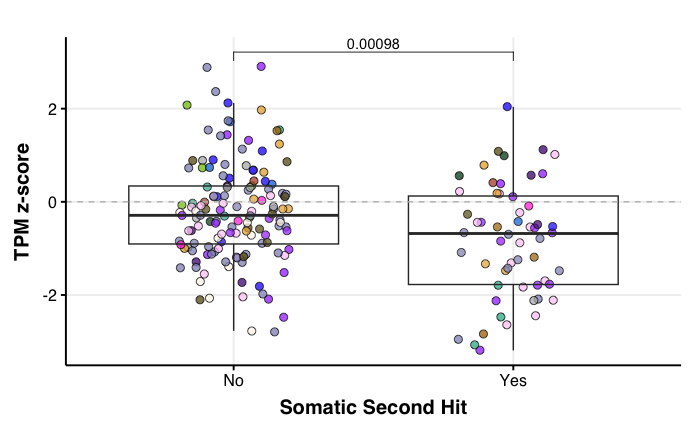

```r
z_scored_expression %>%
  dplyr::filter(is_plp == "Yes") %>%
  ggplot(aes(x = second_hit, y = expr_zscore)) +
  geom_jitter(aes(fill = plot_group), shape = 21,
              width = 0.2, size = 2.5, alpha = 0.75,
              show.legend = FALSE) +
  geom_boxplot(alpha = 0.05, outlier.shape = NA,
                 show.legend = FALSE) +
  stat_compare_means(method = "wilcox",
                     comparisons = list(c("Yes", "No")),
                       method.args = list(alternative = "less")) +
  labs(x = "Somatic Second Hit", y = "TPM z-score", fill = "Histology") +
  geom_hline(yintercept = 0, linetype = "dashed", color = "gray") +
  scale_fill_manual(values = plot_group_palette,
                    breaks = sort(names(plot_group_palette))) +
  theme_Publication()

ggsave(file.path(plot_dir, "gene-expr-second-hit-vs-none.pdf"),
                   width = 4, height = 4)
```